# Analyze A/B Test Results

## Introduction

A/B tests are very commonly performed by data analysts and data scientists. For this project, you will be working to understand the results of an A/B test run by an e-commerce website. Your goal is to work through this notebook to help the company understand if they should:

- Implement the new webpage,
- Keep the old webpage, or
- Perhaps run the experiment longer to make their decision.

## Part I - Probability

To get started, let's import our libraries.

```python
import pandas as pd
import numpy as np
import random
import matplotlib.pyplot as plt
%matplotlib inline
#We are setting the seed to assure you get the same answers on quizzes as we set up
random.seed(42)
```

```python
#reading in the dataset and storing it in a dataframe named 'df'
df = pd.read_csv('ab_data.csv')

#taking a look at what the first few rows of the dataframe looks like!
df.head()
```

|  | user_id | timestamp | group | landing_page | converted |
| --- | --- | --- | --- | --- | --- |
| 0 | 851104 | 2017-01-21 22:11:48.556739 | control | old_page | 0 |
| 1 | 804228 | 2017-01-12 08:01:45.159739 | control | old_page | 0 |
| 2 | 661590 | 2017-01-11 16:55:06.154213 | treatment | new_page | 0 |
| 3 | 853541 | 2017-01-08 18:28:03.143765 | treatment | new_page | 0 |
| 4 | 864975 | 2017-01-21 01:52:26.210827 | control | old_page | 1 |

Let's check the number of rows in the dataset.

```python
#Checking the number of rows in the dataframe
df.shape[0]
```

```
294478
```

Let's check the number of unique users in the dataset.

```python
#Checking the number of unique users in the dataframe
df['user_id'].nunique()
```

```
290584
```

Checking the proportion of users converted.

```python
#Summing up the '1's that signify a user has converted and dividing it by the total number of rows in the dataframe
#in order to get the total conversion rate of the entire population
df['converted'].mean()
```

```
0.11965919355605512
```

The number of times when the "group" is `treatment` but "landing_page" is not a `new_page`.

```python
#filtering by the mismatched conditions to obtain the number of times when that has occurred.
df.query("(group == 'treatment' and landing_page != 'new_page') or (group == 'control' and landing_page != 'old_page')").shape[0]
```

```
3893
```

Do any of the rows have missing values?

```python
#checking to see if any missing values exist
df.isnull().sum().sum()
```

```
0
```

```python
#double checking to see if there were any null values present
df.info()
```

```
<class 'pandas.core.frame.DataFrame'>
RangeIndex: 294478 entries, 0 to 294477
Data columns (total 5 columns):
user_id         294478 non-null int64
timestamp       294478 non-null object
group           294478 non-null object
landing_page    294478 non-null object
converted       294478 non-null int64
dtypes: int64(2), object(3)
memory usage: 11.2+ MB
```

```python
# Remove the inaccurate rows, and store the result in a new dataframe df2
df2 = df.query("(group == 'treatment' and landing_page == 'new_page') or (group == 'control' and landing_page == 'old_page')")
```

```python
# Double Check all of the incorrect rows were removed from df2 -
# Output of the statement below should be 0
df2[((df2['group'] == 'treatment') == (df2['landing_page'] == 'new_page')) == False].shape[0]
```

```
0
```

How many unique **user_id**s are in **df2**?

```python
#getting the number of unique users in the new dataframe
df2['user_id'].nunique()
```

```
290584
```

There is one **user_id** repeated in **df2**. What is it?

```python
#retrieving the row that contains the duplicated user id
df2[df2['user_id'].duplicated()]
```

|  | user_id | timestamp | group | landing_page | converted |
| --- | --- | --- | --- | --- | --- |
| 2893 | 773192 | 2017-01-14 02:55:59.590927 | treatment | new_page | 0 |

Display the rows for the duplicate **user_id**?

```python
#displaying the rows in which the user-id was duplicated
df2[df2.duplicated(['user_id'], keep = False)]
```

|  | user_id | timestamp | group | landing_page | converted |
| --- | --- | --- | --- | --- | --- |
| 1899 | 773192 | 2017-01-09 05:37:58.781806 | treatment | new_page | 0 |
| 2893 | 773192 | 2017-01-14 02:55:59.590927 | treatment | new_page | 0 |

Remove **one** of the rows with a duplicate **user_id**, from the **df2** dataframe.

```python
#removing one of the rows with a duplicate user_id
#dataframe.drop_duplicates() may not work in this case because the rows with duplicate user_id are not entirely identical
#so, we'll drop that row manually using indexing
df2 = df2.drop(1899)
# Check again if the row with a duplicate user_id is deleted or not
df2.duplicated().sum()
```

```
0
```

What is the probability of an individual converting regardless of the page they receive?

```python
#overall conversion success rate in the population
probability_conversion_population = df2['converted'].mean()
probability_conversion_population
```

```
0.11959708724499628
```

Given that an individual was in the `control` group, what is the probability they converted?

```python
#the probability that a user converts given they were in the control group
#this value signifies the conversion rate for the control group
converted_given_control = df2.query("group == 'control' and converted == 1").shape[0]/df2.query("group == 'control'").shape[0]
converted_given_control
```

```
0.1203863045004612
```

Given that an individual was in the `treatment` group, what is the probability they converted?

```python
#the probability that a user converts given they were in the treatment group
#this value signifies the conversion rate for the treatment group
converted_given_treatment = df2.query("group == 'treatment' and converted == 1").shape[0]/df2.query("group == 'treatment'").shape[0]
converted_given_treatment
```

```
0.11880806551510564
```

```python
# Calculate the actual difference (obs_diff) between the conversion rates for the two groups.
obs_diff = converted_given_treatment - converted_given_control
obs_diff
```

```
-0.0015782389853555567
```

What is the probability that an individual received the new page?

```python
#probability of an individual becoming in the treatment group
#which signifies the proportion of users who were given the new page out of the entire population of users
probability_treatment = df2.query("landing_page == 'new_page'").shape[0]/df2.shape[0]
probability_treatment
```

```
0.5000619442226688
```

## **Interpretation:**

### The population size is split almost equally between the control and treatment group. On the other hand, it seems like the conversion rate of the treatment group is a little less than that of the old page. The observed difference is very tiny though.

## Part II - A/B Test

If you want to assume that the old page is better unless the new page proves to be definitely better at a Type I error rate of 5%, what should be your null and alternative hypotheses?

You can state your hypothesis in terms of words or in terms of **$p_{old}$** and **$p_{new}$**, which are the "converted" probability (or rate) for the old and new pages respectively.

𝐻0: 𝑝new - 𝑝old <= 0

𝐻1: 𝑝new- 𝑝old > 0

### ToDo 2.2 - Null Hypothesis $H_0$ Testing

Under the null hypothesis, assuming that:

$p_{new}$ = $p_{old}$ = $p_{population}$

In this section, you will:

- Simulate (bootstrap) sample data set for both groups, and compute the "converted" probability $p$ for those samples.
- Use a sample size for each group equal to the ones in the `df2` data.
- Compute the difference in the "converted" probability for the two samples above.
- Perform the sampling distribution for the "difference in the converted probability" between the two simulated-samples over 10,000 iterations; and calculate an estimate.

Use the cells below to provide the necessary parts of this simulation. You can use **Quiz 5** in the classroom to make sure you are on the right track.

What is the **conversion rate** for $p_{new}$ under the null hypothesis?

```python
#under the new assumption that p_new = p_old = p_population
#then p_new will equal the conversion rate of the population
p_new = df2['converted'].mean()

p_population = df2['converted'].mean()
p_new, p_population
```

```
(0.11959708724499628, 0.11959708724499628)
```

What is the **conversion rate** for $p_{old}$ under the null hypothesis?

```python
#under the new assumption that p_new = p_old = p_population
#then p_old will equal the conversion rate of the population
p_old = df2['converted'].mean()
```

What is $n_{new}$, the number of individuals in the treatment group?

```python
#retrieving the number of unique users that are present in the treatment group
n_new = df2.query("group == 'treatment'")['user_id'].nunique()
n_new
```

```
145310
```

What is $n_{old}$, the number of individuals in the control group?

```python
#retrieving the number of unique users that are present in the control group
n_old = df2.query("group == 'control'")['user_id'].nunique()
n_old
```

```
145274
```

Simulate Sample for the `treatment` Group:

```python
# Simulate a Sample for the treatment Group
#we're basically telling numpy to create a n_new samples made up 0's and 1's where the 1's would have-
#-the probability of p_new and the 0's would have the probability of (1 - p_new)
#noting that: 1's signify successful conversion, and vice versa
new_page_converted = np.random.choice([0,1], size = n_new, p = [(1 - p_new), (p_new)])

#getting the conversion rate of the simulated new page
new_mean = new_page_converted.mean()
new_mean
```

```
0.11889752941986098
```

Simulate Sample for the `control` Group:

```python
# Simulate a Sample for the control Group
#we're basically telling numpy to create a n_old samples made up 0's and 1's where the 1's would have-
#-the probability of p_old and the 0's would have the probability of (1 - p_old)
#noting that: 1's signify successful conversion, and vice versa
old_page_converted = np.random.choice([0,1], size = n_old, p = [(1 - p_old), (p_old)])

#getting the conversion rate of the simulated old page
old_mean = old_page_converted.mean()
old_mean
```

```
0.12153585638173382
```

Find the difference in the "converted" probability $(p{'}_{new}$ - $p{'}_{old})$

```python
#getting the difference in simulated conversion probabilities/rates
diff = new_mean - old_mean
diff
```

```
-0.0026383269618728417
```

**Sampling distribution**  
Re-creating `new_page_converted` and `old_page_converted` and finding the $(p{'}_{new}$ - $p{'}_{old})$ value 10,000 times using the same simulation process used above.

Storing all $(p{'}_{new}$ - $p{'}_{old})$ values in a NumPy array called `p_diffs`.

```python
# Sampling distribution
#creating an empty list to store the difference in probabilities/conversion rates in
p_diffs = []

#looping over the indented portion 10000 times
for element in range(10000):

    #getting the conversion rate of a sample of the new page
    new_page_converted = (np.random.choice([0, 1], size = n_new, p = [(1 - p_new), (p_new)])).mean()

    #getting the conversion rate of a sample of the old page
    old_page_converted = (np.random.choice([0, 1], size = n_old, p = [(1 - p_old), (p_old)])).mean()

    #appending the difference in calculated conversion rates to the previously created list
    p_diffs.append(new_page_converted - old_page_converted)
```

**Histogram**  
Plotting a histogram of the **p_diffs**.

```
Text(0,0.5,'Counts')
```

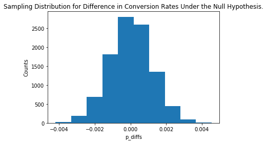

```python
#changing p_diffs into a numpy array
p_diffs = np.array(p_diffs)

#let's plot a histogram to see what the sampling distribution of the difference in conversion rates look like!
plt.hist(p_diffs)

#adding a title for the histogram
plt.title("Sampling Distribution for Difference in Conversion Rates Under the Null Hypothesis.")

#adding x and y labels
plt.xlabel("p_diffs")
plt.ylabel("Counts")
```

According to the central limit theorem, the sampling distribution should be normally distributed for large sample size. This graph, hence, is what we expected.

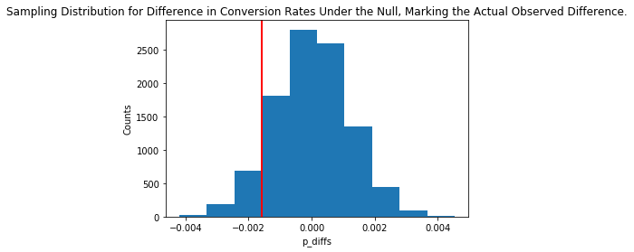

```python
#let's plot a histogram to see what the sampling distribution of the difference in conversion rates look like!
plt.hist(p_diffs)

#adding a title for the histogram
plt.title("Sampling Distribution for Difference in Conversion Rates Under the Null, Marking the Actual Observed Difference.")

#adding x and y labels
plt.xlabel("p_diffs")
plt.ylabel("Counts")

#Let's add a vertical line that marks the observed difference in conversion rates calculated earlier.
plt.axvline(obs_diff, color = 'r', linewidth = 2)
```

What proportion of the **p_diffs** are greater than the actual difference observed in the `df2` data?

```python
#calculating the p-value
(p_diffs > obs_diff).mean()
```

```
0.9103
```

*Please explain in words what you have just computed in the part above.

- What is this value called in scientific studies?
- What does this value signify in terms of whether or not there is a difference between the new and old pages?

**l. Using Built-in Methods for Hypothesis Testing**  
We could also use a built-in to achieve similar results. Though using the built-in might be easier to code, the above portions are a walkthrough of the ideas that are critical to correctly thinking about statistical significance.

Fill in the statements below to calculate the:

- `convert_old`: number of conversions with the old_page
- `convert_new`: number of conversions with the new_page
- `n_old`: number of individuals who were shown the old_page
- `n_new`: number of individuals who were shown the new_page

```python
import statsmodels.api as sm

# number of conversions with the old_page
convert_old = df2.query("group == 'control' and converted == 1").shape[0]

# number of conversions with the new_page
convert_new = df2.query("group == 'treatment' and converted == 1").shape[0]

# number of individuals who were shown the old_page
n_old = df2.query("group == 'control'").shape[0]

# number of individuals who received new_page
n_new = df2.query("group == 'treatment'").shape[0]
```

```python
import statsmodels.api as sm
#since our null hypothesis for a one tailed test states that: p_new - p_old <= 0
#then our alternative hypothesis would be that: p_new - p_old > 0
#which renders our test a right-tailed test, so for the alternative, the parameter 'larger' will be chosen.
z_score, p_value = sm.stats.proportions_ztest([convert_new, convert_old], [n_new, n_old], alternative = 'larger')
print(z_score, p_value)
```

```
-1.31092419842 0.905058312759
```

What do the z-score and p-value you computed in the previous question mean for the conversion rates of the old and new pages? Do they agree with the findings in parts **j.** and **k.**?

### The computed z-score = -1.3109, for a right-tailed test, in order to reject the null hypothesis the z-score would have to be larger than the z-alpha value = 1.645 for one-tailed tests. Since z-score < z-alpha, we fail to reject the null hypothesis, which signifies that we don't have enough evidence to reject the null hypothesis that old page is performing better, or just as well, as the new page.

### The p-value computed by the z-test is the same value that was computed earlier. According to both test outcomes, we fail to reject the null hypothesis. Both results lead to the same outcome, so both tests agree on findings.

### Part III - A regression approach

**a.** Since each row in the `df2` data is either a conversion or no conversion, what type of regression should you be performing in this case?

### Since we're trying to predict whether a user would convert or not, where the answer would be just one of two possible values, the type of regression that will be performed is logistic regression.

**b.** The goal is to use **statsmodels** library to fit the regression model you specified in part **a.** above to see if there is a significant difference in conversion based on the page-type a customer receives. However, you first need to create the following two columns in the `df2` dataframe:

1. `intercept` - It should be `1` in the entire column.
2. `ab_page` - It's a dummy variable column, having a value `1` when an individual receives the **treatment**, otherwise `0`.

```python
#taking a look at the dataframe
df2.head()
```

|  | user_id | timestamp | group | landing_page | converted |
| --- | --- | --- | --- | --- | --- |
| 0 | 851104 | 2017-01-21 22:11:48.556739 | control | old_page | 0 |
| 1 | 804228 | 2017-01-12 08:01:45.159739 | control | old_page | 0 |
| 2 | 661590 | 2017-01-11 16:55:06.154213 | treatment | new_page | 0 |
| 3 | 853541 | 2017-01-08 18:28:03.143765 | treatment | new_page | 0 |
| 4 | 864975 | 2017-01-21 01:52:26.210827 | control | old_page | 1 |

```python
#creating a column for the intercept
df2['intercept'] = 1

#creating a dummy variable column 'ab_page 'that equals 1 when an individual receives the treatment column and 0 otherwise
df2[['control', 'ab_page']] = pd.get_dummies(df2['group'])
```

```python
df2.head()
```

|  | user_id | timestamp | group | landing_page | converted | intercept | control | ab_page |
| --- | --- | --- | --- | --- | --- | --- | --- | --- |
| 0 | 851104 | 2017-01-21 22:11:48.556739 | control | old_page | 0 | 1 | 1 | 0 |
| 1 | 804228 | 2017-01-12 08:01:45.159739 | control | old_page | 0 | 1 | 1 | 0 |
| 2 | 661590 | 2017-01-11 16:55:06.154213 | treatment | new_page | 0 | 1 | 0 | 1 |
| 3 | 853541 | 2017-01-08 18:28:03.143765 | treatment | new_page | 0 | 1 | 0 | 1 |
| 4 | 864975 | 2017-01-21 01:52:26.210827 | control | old_page | 1 | 1 | 1 | 0 |

```python
#dropping the 'control' column, since all the information that we need is portrayed in the 'ab_page' column
#also to ensure that our model array is full-rank
df2.drop(['control'], axis = 1, inplace = True)
```

```python
#checking if this worked out as desired.
df2.head()
```

|  | user_id | timestamp | group | landing_page | converted | intercept | ab_page |
| --- | --- | --- | --- | --- | --- | --- | --- |
| 0 | 851104 | 2017-01-21 22:11:48.556739 | control | old_page | 0 | 1 | 0 |
| 1 | 804228 | 2017-01-12 08:01:45.159739 | control | old_page | 0 | 1 | 0 |
| 2 | 661590 | 2017-01-11 16:55:06.154213 | treatment | new_page | 0 | 1 | 1 |
| 3 | 853541 | 2017-01-08 18:28:03.143765 | treatment | new_page | 0 | 1 | 1 |
| 4 | 864975 | 2017-01-21 01:52:26.210827 | control | old_page | 1 | 1 | 0 |

great!

**c.** Use **statsmodels** to instantiate your regression model on the two columns you created in part (b). above, then fit the model to predict whether or not an individual converts.

```python
import statsmodels.api as sm
```

```python
#instantiating the model
model = sm.Logit(df2['converted'], df2[['intercept', 'ab_page']])
#fitting the model
results = model.fit()
```

```
Optimization terminated successfully.
         Current function value: 0.366118
         Iterations 6
```

**d.** Provide the summary of your model below, and use it as necessary to answer the following questions.

```python
#displaying summary for the model
results.summary2()
```

| Model: | Logit | No. Iterations: | 6.0000 |
| --- | --- | --- | --- |
| Dependent Variable: | converted | Pseudo R-squared: | 0.000 |
| Date: | 2022-03-19 16:22 | AIC: | 212780.3502 |
| No. Observations: | 290584 | BIC: | 212801.5095 |
| Df Model: | 1 | Log-Likelihood: | -1.0639e+05 |
| Df Residuals: | 290582 | LL-Null: | -1.0639e+05 |
| Converged: | 1.0000 | Scale: | 1.0000 |

|  | Coef. | Std.Err. | z | P>\|z\| | [0.025 | 0.975] |
| --- | --- | --- | --- | --- | --- | --- |
| intercept | -1.9888 | 0.0081 | -246.6690 | 0.0000 | -2.0046 | -1.9730 |
| ab_page | -0.0150 | 0.0114 | -1.3109 | 0.1899 | -0.0374 | 0.0074 |

What is the p-value associated with **ab_page**? Why does it differ from the value you found in **Part II**?

### The p-value associated with 'ab_page' is 0.1899, and yes, it's different. On the other hand, it's still greater than the error rate specificed as 0.05, which leads to the same conclusion as earlier: failing to reject the null hypothesis.

### The null hypothesis associated with part 2 was that the conversion rate of the old page was greater or equal to the new page, which can be interpreted as one-sided or one-tailed. On the otherf hand, this model uses an intercept, and accordingly the **alternative** hypothesis would be that there's a positive, or negative, relationship between the conversion rates of the old page and that of the new page. In other words, the alternative hypothesis is associated with any *difference*, this can be signified as a *two-tailed hypothesis*.

### The difference in p-values could be attributed to the change in one being a one-tailed test and the other being two-tailed.

**f.** Now, you are considering other things that might influence whether or not an individual converts. Discuss why it is a good idea to consider other factors to add into your regression model. Are there any disadvantages to adding additional terms into your regression model?

### It's a good idea to consider other factors to add into the regression model, because the purpose of the model is to gain insight on how the predictor variables influence the dependent variable to be predicted, which in our case, is whether a user converts or not. Considering other factors could unravel more information about what factors could enhance the predictivity of our model, and what would have no effect.

### The disadvantage would be that the model would become more complicated as you increase the number of predictors.

**g. Adding countries**  
Now along with testing if the conversion rate changes for different pages, also add an effect based on which country a user lives in.

1. You will need to read in the **countries.csv** dataset and merge together your `df2` datasets on the appropriate rows. You call the resulting dataframe `df_merged`. [Here](https://pandas.pydata.org/pandas-docs/stable/reference/api/pandas.DataFrame.join.html) are the docs for joining tables.
2. Does it appear that country had an impact on conversion? To answer this question, consider the three unique values, `['UK', 'US', 'CA']`, in the `country` column. Create dummy variables for these country columns.

Provide the statistical output as well as a written response to answer this question.

```python
# Read the countries.csv
countries_df = pd.read_csv('countries.csv')
countries_df.head()
```

|  | user_id | country |
| --- | --- | --- |
| 0 | 834778 | UK |
| 1 | 928468 | US |
| 2 | 822059 | UK |
| 3 | 711597 | UK |
| 4 | 710616 | UK |

```python
# Join with the df2 dataframe
df_merged = pd.merge(df2, countries_df, on = ['user_id'], how = 'inner')
```

```python
#view the merged dataframe
df_merged.head()
```

|  | user_id | timestamp | group | landing_page | converted | intercept | ab_page | country |
| --- | --- | --- | --- | --- | --- | --- | --- | --- |
| 0 | 851104 | 2017-01-21 22:11:48.556739 | control | old_page | 0 | 1 | 0 | US |
| 1 | 804228 | 2017-01-12 08:01:45.159739 | control | old_page | 0 | 1 | 0 | US |
| 2 | 661590 | 2017-01-11 16:55:06.154213 | treatment | new_page | 0 | 1 | 1 | US |
| 3 | 853541 | 2017-01-08 18:28:03.143765 | treatment | new_page | 0 | 1 | 1 | US |
| 4 | 864975 | 2017-01-21 01:52:26.210827 | control | old_page | 1 | 1 | 0 | US |

```python
# Create the necessary dummy variables
df_merged[['CA', 'UK', 'US']] = pd.get_dummies(df_merged['country'])
```

```python
#see if that worked out the way we desire.
df_merged.head(10)
```

|  | user_id | timestamp | group | landing_page | converted | intercept | ab_page | country | CA | UK | US |
| --- | --- | --- | --- | --- | --- | --- | --- | --- | --- | --- | --- |
| 0 | 851104 | 2017-01-21 22:11:48.556739 | control | old_page | 0 | 1 | 0 | US | 0 | 0 | 1 |
| 1 | 804228 | 2017-01-12 08:01:45.159739 | control | old_page | 0 | 1 | 0 | US | 0 | 0 | 1 |
| 2 | 661590 | 2017-01-11 16:55:06.154213 | treatment | new_page | 0 | 1 | 1 | US | 0 | 0 | 1 |
| 3 | 853541 | 2017-01-08 18:28:03.143765 | treatment | new_page | 0 | 1 | 1 | US | 0 | 0 | 1 |
| 4 | 864975 | 2017-01-21 01:52:26.210827 | control | old_page | 1 | 1 | 0 | US | 0 | 0 | 1 |
| 5 | 936923 | 2017-01-10 15:20:49.083499 | control | old_page | 0 | 1 | 0 | US | 0 | 0 | 1 |
| 6 | 679687 | 2017-01-19 03:26:46.940749 | treatment | new_page | 1 | 1 | 1 | CA | 1 | 0 | 0 |
| 7 | 719014 | 2017-01-17 01:48:29.539573 | control | old_page | 0 | 1 | 0 | US | 0 | 0 | 1 |
| 8 | 817355 | 2017-01-04 17:58:08.979471 | treatment | new_page | 1 | 1 | 1 | UK | 0 | 1 | 0 |
| 9 | 839785 | 2017-01-15 18:11:06.610965 | treatment | new_page | 1 | 1 | 1 | CA | 1 | 0 | 0 |

```python
#Instantiating the model
new_model = sm.Logit(df_merged['converted'], df_merged[['intercept', 'ab_page', 'CA', 'UK']] )
result = new_model.fit()
result.summary2()
```

```
Optimization terminated successfully.
         Current function value: 0.366113
         Iterations 6
```

| Model: | Logit | No. Iterations: | 6.0000 |
| --- | --- | --- | --- |
| Dependent Variable: | converted | Pseudo R-squared: | 0.000 |
| Date: | 2022-03-19 16:22 | AIC: | 212781.1253 |
| No. Observations: | 290584 | BIC: | 212823.4439 |
| Df Model: | 3 | Log-Likelihood: | -1.0639e+05 |
| Df Residuals: | 290580 | LL-Null: | -1.0639e+05 |
| Converged: | 1.0000 | Scale: | 1.0000 |

|  | Coef. | Std.Err. | z | P>\|z\| | [0.025 | 0.975] |
| --- | --- | --- | --- | --- | --- | --- |
| intercept | -1.9893 | 0.0089 | -223.7628 | 0.0000 | -2.0067 | -1.9718 |
| ab_page | -0.0149 | 0.0114 | -1.3069 | 0.1912 | -0.0374 | 0.0075 |
| CA | -0.0408 | 0.0269 | -1.5161 | 0.1295 | -0.0934 | 0.0119 |
| UK | 0.0099 | 0.0133 | 0.7433 | 0.4573 | -0.0162 | 0.0359 |

```python
#In logistic regression, in order to interpret the coefficients, we need the exponent of the coefficient first.

1/np.exp(-0.0408), np.exp(0.0099)
```

```
(1.0416437559600236, 1.0099491671175422)
```

### The exponentiation to the coefficients can be interpreted as:

### In comparison to a user living in the **US**, A user living in **CA** is **LESS** likely to convert by a factor of 1.0416, while a user living in the **UK** is **MORE** likely to convert by a factor of 1.00995.

### On the other hand, the p-values associated with the country dummy variables ara all greater than the error rate of 0.05, signifying that there isn't statistical evidence enough to reject the null hypothesis.

**Fit your model and obtain the results**  
Though you have now looked at the individual factors of country and page on conversion, we would now like to look at an interaction between page and country to see if are there significant effects on conversion.

Provide the summary results (statistical output), and your conclusions (written response) based on the results.

```python
#creating an interaction between page and UK country by multiplying the two columns together
df_merged['UK_ab_page'] = df_merged['UK']*df_merged['ab_page']

#creating an interaction between page and CA country by multiplying the two columns together
df_merged['CA_ab_page'] = df_merged['CA']*df_merged['ab_page']

#instantiating the model
modified_model = sm.Logit(df_merged['converted'], df_merged[['intercept', 'ab_page', 'UK', 'CA', 'UK_ab_page', 'CA_ab_page']])

#fitting the model
results = modified_model.fit()

#displaying the summary
results.summary2()
```

```
Optimization terminated successfully.
         Current function value: 0.366109
         Iterations 6
```

| Model: | Logit | No. Iterations: | 6.0000 |
| --- | --- | --- | --- |
| Dependent Variable: | converted | Pseudo R-squared: | 0.000 |
| Date: | 2022-03-19 16:22 | AIC: | 212782.6602 |
| No. Observations: | 290584 | BIC: | 212846.1381 |
| Df Model: | 5 | Log-Likelihood: | -1.0639e+05 |
| Df Residuals: | 290578 | LL-Null: | -1.0639e+05 |
| Converged: | 1.0000 | Scale: | 1.0000 |

|  | Coef. | Std.Err. | z | P>\|z\| | [0.025 | 0.975] |
| --- | --- | --- | --- | --- | --- | --- |
| intercept | -1.9865 | 0.0096 | -206.3440 | 0.0000 | -2.0053 | -1.9676 |
| ab_page | -0.0206 | 0.0137 | -1.5052 | 0.1323 | -0.0473 | 0.0062 |
| UK | -0.0057 | 0.0188 | -0.3057 | 0.7598 | -0.0426 | 0.0311 |
| CA | -0.0175 | 0.0377 | -0.4652 | 0.6418 | -0.0914 | 0.0563 |
| UK_ab_page | 0.0314 | 0.0266 | 1.1807 | 0.2377 | -0.0207 | 0.0835 |
| CA_ab_page | -0.0469 | 0.0538 | -0.8718 | 0.3833 | -0.1523 | 0.0585 |

### None of the added terms has a p-value that's less than the error rate od 0.05 which still leads us to the same conclusion, that we don't have enough evidence to reject the null hypothesis.

```python
from subprocess import call
call(['python', '-m', 'nbconvert', 'Analyze_ab_test_results_notebook.ipynb'])
```

```
0
```